# Self-Driving Car Engineer Nanodegree

## Project: Build a Traffic Sign Recognition Classifier

### Overview

In this project I'm using deep neural networks and convolutional neural networks to classify traffic signs. I provided below step by step guide showing the approach i used to to train and validate a model so it can classify traffic sign images using the German Traffic Sign Dataset.

### Project Goals

steps of this project are the following:

```
* Load the data set (see below for links to the project data set)
* Explore, summarize and visualize the data set
* Design, train and test a model architecture
* Use the model to make predictions on new images
* Analyze the softmax probabilities of the new images
* Summarize the results with a written report
```

```python
#imports

# Load pickled data
import pickle
import csv
import pandas as pd
import numpy as np

import random
import math


import os
import os.path
import sys

import cv2
import matplotlib.pyplot as plt
import matplotlib.image as mpimg
from PIL import ImageOps
from PIL import Image

from scipy.misc import imresize
from skimage import data
from skimage import color
from skimage import img_as_float



import tensorflow as tf
from tensorflow.contrib.layers import flatten
```

## Step 0: Load The Data

```python
# TODO: Fill this in based on where you saved the training and testing data

training_file = './traffic-signs-data/train.p'
validation_file='./traffic-signs-data/valid.p'
testing_file = './traffic-signs-data/test.p'

with open(training_file, mode='rb') as f:
    train = pickle.load(f)
with open(validation_file, mode='rb') as f:
    valid = pickle.load(f)
with open(testing_file, mode='rb') as f:
    test = pickle.load(f)

X_train, y_train = train['features'], train['labels']
X_validation, y_validation = valid['features'], valid['labels']
X_test, y_test = test['features'], test['labels']
```

## Step 1: Dataset Summary & Exploration

The pickled data is a dictionary with 4 key/value pairs:

- `'features'` is a 4D array containing raw pixel data of the traffic sign images, (num examples, width, height, channels).
- `'labels'` is a 1D array containing the label/class id of the traffic sign. The file `signnames.csv` contains id -> name mappings for each id.
- `'sizes'` is a list containing tuples, (width, height) representing the original width and height the image.
- `'coords'` is a list containing tuples, (x1, y1, x2, y2) representing coordinates of a bounding box around the sign in the image. **THESE COORDINATES ASSUME THE ORIGINAL IMAGE. THE PICKLED DATA CONTAINS RESIZED VERSIONS (32 by 32) OF THESE IMAGES**

### Provide a Basic Summary of the Data Set Using Python, Numpy and/or Pandas

### Question 1.1 - Provide a basic summary of the data set. In the code, the analysis should be done using python, numpy and/or pandas methods rather than hardcoding results manually.

I used numpy library to calculate summmary statistics of the traffic signs data set

- Number of training examples = 34799
- Number of testing examples = 12630
- Number of validation examples = 4410
- Image data shape = (32, 32, 3)
- Number of unique classes = 43

```python
assert(len(X_train) == len(y_train))
assert(len(X_validation) == len(y_validation))
assert(len(X_test) == len(y_test))


# TODO: Number of training examples
n_train = len(X_train)

# TODO: Number of validation examples
n_validation = len(X_validation)

# TODO: Number of testing examples.
n_test = len(X_test)

# TODO: What's the shape of an traffic sign image?
image_shape = X_train[0].shape

# TODO: How many unique classes/labels there are in the dataset.
n_classes = len(np.unique(y_train))

print()
print("Number of training examples =", n_train)
print("Number of testing examples =", n_test)
print("Number of validation examples =", len(X_validation))
print("Image data shape =", image_shape)
print("Number of unique classes =", n_classes)
```

```
Number of training examples = 34799
Number of testing examples = 12630
Number of validation examples = 4410
Image data shape = (32, 32, 3)
Number of unique classes = 43
```

### Question 1.2. Include an exploratory visualization of the dataset.

I implemented mutiple helper function to help with visualizing data set images and mapping image labels from the provided CSV file.

- displayCSV
- getSignNameById
- showSampleImages

```python
### Data exploration visualization code goes here.
### Feel free to use as many code cells as needed.


# Visualizations will be shown in the notebook.
%matplotlib inline


#Get Sign Name By ClassID
def displayCSV(fileName):
    signs_dict={}
    with open(fileName, 'rt') as csvfile:
        reader = csv.DictReader(csvfile, delimiter=',')
        print("Label ID         SignName");
        for row in reader:
            print(row['ClassId']+"         "+row['SignName'])
            #signs_dict[row['ClassId']]=row['SignName']
    #return signs_dict[Id]


#Get Sign Name By ClassID
def getSignNameById(Id):
    signs_dict={}
    with open('signnames.csv', 'rt') as csvfile:
        reader = csv.DictReader(csvfile, delimiter=',')
        for row in reader:
            signs_dict[row['ClassId']]=row['SignName']
    return signs_dict[Id]




#Show random Traffic Sign images from the Train Data Set
def showSampleImage (imageList                   ,   # X_train
                     imageTitleList              ,   # y_train
                     number_of_samples  =  10    ,   # Limit number of visualized samples (Optional)
                     randomize          =  False ,   # Pick random images from list (Optional)
                     filter_class       = None   ,   # Filter the image list for specific class (Optional)
                     actual_title_list  = None   ,   # Used to determine the correct prediction and highlight image border (Green/Red)
                     hSize              = 16     ,   # Image High (Optional)
                     wSize              = 16     ,   # Image Width (Optional)
                     n_row              = None   ,   # force number of rows (Optional)
                     image_title        = True   ) : # Disable/Enable image title
    hSize=16
    wSize=16
    GREEN = [0,255,0]
    RED = [255,0,0]



    if number_of_samples<= 5:
        number_of_col = number_of_samples
        number_of_row = 1
    else:
        number_of_col = 5
        number_of_row = math.ceil(number_of_samples/number_of_col)

    if n_row != None:
        number_of_row = n_row
        number_of_col = number_of_samples


    fig, axs= plt.subplots(number_of_row,
                           number_of_col,
                           figsize=(hSize,wSize))

    fig.subplots_adjust(hspace = 0.1,
                        wspace = 0.1 )
    axs = axs.ravel()



    cnt=0
    if filter_class !=None:
        if randomize == True :
            images_in_this_sign_class = imageList[imageTitleList == filter_class, ...]
            filtered_image_title_list = imageTitleList[imageTitleList == filter_class, ...]
            #print(len(images_in_this_sign_class))
            #print(getSignNameById(str(filter_class)))
            for i in range(0,number_of_samples):
                index = random.randint(0, len(images_in_this_sign_class)-1)
                image = images_in_this_sign_class[index]
                axs[i].axis('off')
                axs[i].imshow(image)
                if image_title != False:
                    axs[i].set_title(getSignNameById(str(filtered_image_title_list[index])))

        else :
            for i in range(0,len(imageList)):
                if imageTitleList[i] == filter_class:
                    image = imageList[i]
                    axs[cnt].axis('off')
                    axs[cnt].imshow(image)
                    #axs[cnt].set_title(getSignNameById(str(imageTitleList[index]))+' '+str(image.shape))
                    if image_title != False:
                        axs[cnt].set_title(getSignNameById(str(imageTitleList[i])))
                    cnt+=1
                    if cnt>number_of_samples-1:
                        break
    elif filter_class == None:
        for i in range(0,number_of_samples):
            index = i
            if randomize:
                index = random.randint(0, len(imageList))
            image = imageList[index]
            axs[i].axis('off')
            if actual_title_list != None:
                if imageTitleList[index] == actual_title_list[index] :
                    image= cv2.copyMakeBorder(image,2,2,2,2,cv2.BORDER_CONSTANT,value=GREEN)
                else:
                    image= cv2.copyMakeBorder(image,2,2,2,2,cv2.BORDER_CONSTANT,value=RED)

            axs[i].imshow(image)
            #axs[i].set_title(getSignNameById(str(imageTitleList[index]))+' '+str(image.shape))
            axs[i].set_title(getSignNameById(str(imageTitleList[index])))
```

#### Visualizing random images from the dataset using the previously defined helper function "ShowSampleImage"

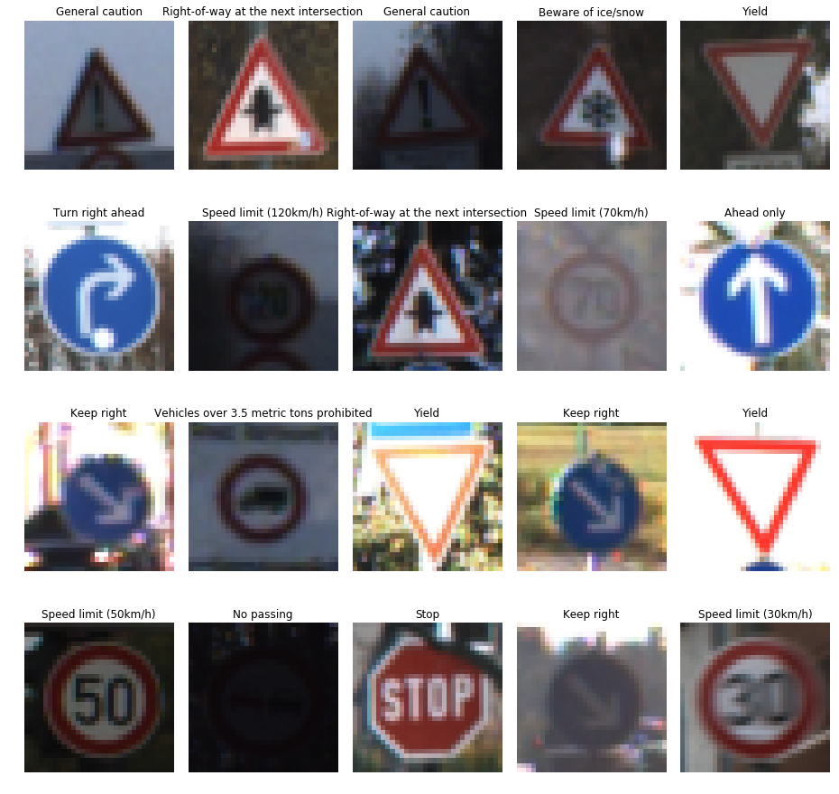

```python
#show  random Images from the data set
showSampleImage(X_train,y_train,number_of_samples=20,randomize=True,filter_class=None)
```

#### show random Images from the data set filter for a specific class

Let's explore samples from each class

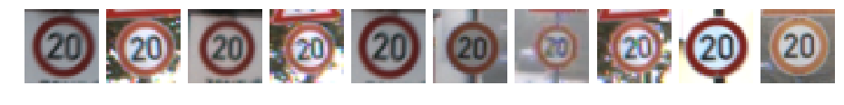

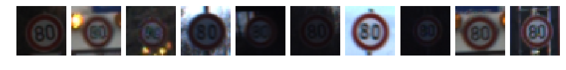

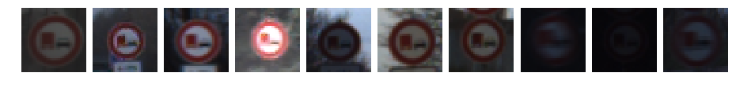

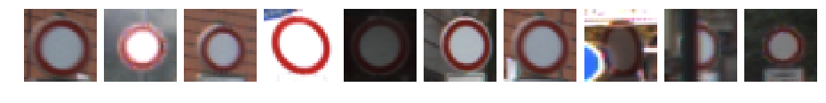

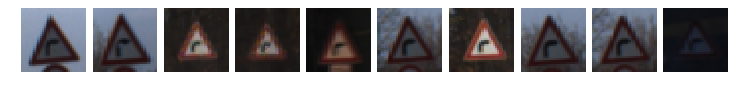

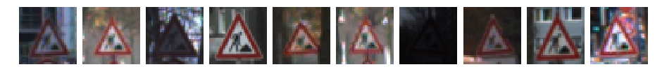

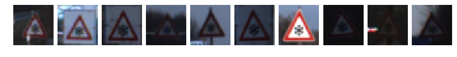

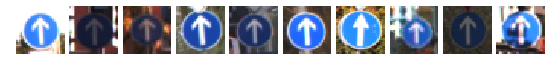

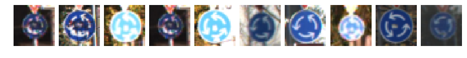

```python
#show  random Images from the data set filter for a specific class
#Let's explore samples from each class
showSampleImage(X_train,y_train,10,filter_class=0,randomize=True,hSize=8,wSize=8,n_row=1,image_title=False)
showSampleImage(X_train,y_train,10,filter_class=5,randomize=True,hSize=8,wSize=8,n_row=1,image_title=False)
showSampleImage(X_train,y_train,10,filter_class=10,randomize=True,hSize=8,wSize=8,n_row=1,image_title=False)

showSampleImage(X_train,y_train,10,filter_class=15,randomize=True,hSize=8,wSize=8,n_row=1,image_title=False)
showSampleImage(X_train,y_train,10,filter_class=20,randomize=True,hSize=8,wSize=8,n_row=1,image_title=False)
showSampleImage(X_train,y_train,10,filter_class=25,randomize=True,hSize=8,wSize=8,n_row=1,image_title=False)

showSampleImage(X_train,y_train,10,filter_class=30,randomize=True,hSize=8,wSize=8,n_row=1,image_title=False)
showSampleImage(X_train,y_train,10,filter_class=35,randomize=True,hSize=8,wSize=8,n_row=1,image_title=False)
showSampleImage(X_train,y_train,10,filter_class=40,randomize=True,hSize=8,wSize=8,n_row=1,image_title=False)
```

#### Display CSV file content

```python
displayCSV('signnames.csv')
```

```
Label ID         SignName
0         Speed limit (20km/h)
1         Speed limit (30km/h)
2         Speed limit (50km/h)
3         Speed limit (60km/h)
4         Speed limit (70km/h)
5         Speed limit (80km/h)
6         End of speed limit (80km/h)
7         Speed limit (100km/h)
8         Speed limit (120km/h)
9         No passing
10         No passing for vehicles over 3.5 metric tons
11         Right-of-way at the next intersection
12         Priority road
13         Yield
```

[output cut: 29 more lines]

```
                   FREQUENCY DISTRIBUTION OF SIGN LABELS
```

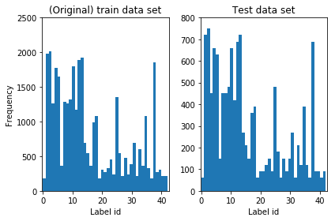

```python
# Train data set - frequency distribution
plt.subplot(121)
plt.hist(y_train, n_classes)
plt.xlabel('Label id')
plt.ylabel('Frequency')
plt.title('(Original) train data set')
plt.axis([-0.25, n_classes-.5, 0,2500])
plt.grid(False)

# Test data set - frequency distribution
plt.subplot(122)
plt.hist(y_test, n_classes)
plt.xlabel('Label id')
plt.title('Test data set')
plt.axis([-0.25, n_classes-.5, 0,800])
plt.grid(False)

plt.tight_layout()
print (" \n")
print("                   FREQUENCY DISTRIBUTION OF SIGN LABELS\n")
plt.show()
```

## Data Set Augmentation

```python
## Todo
# Augment the dataset by rotating or shifting images or by changing colors

'''

[References for image effects]

http://opencv-python-tutroals.readthedocs.io/en/latest/py_tutorials/py_imgproc/py_geometric_transformations/py_geometric_transformations.html
https://github.com/aleju/imgaug/tree/master/imgaug/augmenters
https://docs.opencv.org/3.1.0/d4/d13/tutorial_py_filtering.html
https://www.pyimagesearch.com/2017/01/02/rotate-images-correctly-with-opencv-and-python/
https://www.pyimagesearch.com/2014/01/20/basic-image-manipulations-in-python-and-opencv-resizing-scaling-rotating-and-cropping/
https://www.pyimagesearch.com/2015/10/05/opencv-gamma-correction/

'''

#Dictionary used to collect frequency of each applied effect during augmentation process
augmentation_stats={'Translate':0,'Rotate':0,'Affin_Transform':0,'Blur':0,'Gamma_Correction':0}


def image_effect(img, image_effect=None):

        '''
        -> Perform one of the image effects as specified by image_effect param.
        -> choose a random effect if image_effect=None

        image_effect :
                Invert
                *Add
                *Multiply
                GaussianBlur
                MedianBlur
                Sharpen
                AdditiveGaussianNoise
                *Dropout
                Rotate
                Affin Transform
                Posterize
                Solarize
                Flip
                Equalize
                mirror
        '''

        #select a random effect if none specified
        #Active Random Image Effect
        if image_effect == None:
            image_effect = random.choice(['Translate','Rotate','Affin_Transform','g_Blur','Gamma_Correction'])

        #AutoContrast
        if image_effect == 'AutoContrast':
            pil_image=Image.fromarray(img)
            pil_image= ImageOps.autocontrast(pil_image)
            img= np.array(pil_image)


        #Posterize
        if image_effect == 'Posterize':
            pil_image=Image.fromarray(img)
            pil_image= ImageOps.posterize(pil_image,2)
            img= np.array(pil_image)



        #Invert
        if image_effect == 'Invert':
            pil_image=Image.fromarray(img)
            pil_image= ImageOps.invert(pil_image)
            img= np.array(pil_image)

        #Solarize
        if image_effect == 'Solarize':
            pil_image=Image.fromarray(img)
            pil_image= ImageOps.solarize(pil_image,threshold=128)
            img= np.array(pil_image)

        #flip Vertically
        if image_effect == 'Flip':
            pil_image=Image.fromarray(img)
            pil_image= ImageOps.flip(pil_image)
            img= np.array(pil_image)

        #Mirror
        if image_effect == 'Mirror':
            pil_image=Image.fromarray(img)
            pil_image= ImageOps.mirror(pil_image)
            img= np.array(pil_image)


        #equalize
        if image_effect in 'Equalize' :
            pil_image=Image.fromarray(img)
            pil_image= ImageOps.equalize(pil_image)
            img= np.array(pil_image)


        #Brightness
        if image_effect == 'Brightness':
            hsv = cv2.cvtColor(img,cv2.COLOR_RGB2HSV)
            hsv[:,:,2] = hsv[:,:,2]*.25+np.random.uniform()
            img = cv2.cvtColor(hsv,cv2.COLOR_HSV2RGB)
            augmentation_stats['Brightness'] +=1

        #Translate
        #https://docs.opencv.org/3.1.0/da/d6e/tutorial_py_geometric_transformations.html
        if image_effect == 'Translate':
            x = img.shape[0]
            y = img.shape[1]

            x_trans = np.random.uniform(-0.2 * x, 0.2 * x)
            y_trans = np.random.uniform(-0.2 * y, 0.2 * y)

            trans_matrix = np.float32([[1, 0, x_trans], [0, 1, y_trans]])
            trans_img = cv2.warpAffine(img, trans_matrix, (x, y))
            img = trans_img
            augmentation_stats['Translate'] +=1

        #Rotate
        #http://answers.opencv.org/question/173844/rotation-bicubic-resampling-using-opencv-python/
        if image_effect == 'Rotate':
            rows, cols, ch = img.shape
            rotation_matrix_2d = cv2.getRotationMatrix2D((rows / 2, cols / 2), np.random.uniform(-45, 45), 1)
            dst = cv2.warpAffine(img, rotation_matrix_2d, (cols, rows))
            img = dst
            augmentation_stats['Rotate'] +=1



        #Affin_Transform
        if image_effect == 'Affin_Transform':
            rows, cols, ch = img.shape
            affin_trans = np.random.randint(5,15)
            pts1 = np.array([[5, 5], [20, 5], [5, 20]]).astype('float32')
            pt1 = 5 + affin_trans * np.random.uniform() - affin_trans / 2
            pt2 = 20 + affin_trans * np.random.uniform() - affin_trans / 2
            pts2 = np.float32([[pt1, 5], [pt2, pt1], [5, pt2]])
            M = cv2.getAffineTransform(pts1,pts2)
            dst = cv2.warpAffine(img,M,(cols,rows))
            img = dst
            augmentation_stats['Affin_Transform'] +=1

        #Gaussian_Blur
        if image_effect == 'g_Blur':
            r_int = np.random.randint(0, 2)
            odd_size = 2 * r_int + 1
            img = cv2.GaussianBlur(img, (odd_size, odd_size), 0)
            augmentation_stats['Blur'] +=1

        #Median Blur
        if image_effect == 'm_Blur':
            r_int = np.random.randint(0, 2)
            odd_size = 2 * r_int + 1
            img = cv2.medianBlur(img, (odd_size, odd_size), 0)
            augmentation_stats['Blur'] +=1


        #Gamma
        # https://www.pyimagesearch.com/2015/10/05/opencv-gamma-correction/
        if image_effect == 'Gamma_Correction':
            gamma = np.random.uniform(0.1, 3.0)
            invGamma = 1.0 / gamma
            table = np.array([((i / 255.0) ** invGamma) * 255 for i in np.arange(0, 256)]).astype("uint8")
            img = cv2.LUT(img, table)
            augmentation_stats['Gamma_Correction'] +=1

        return img
```

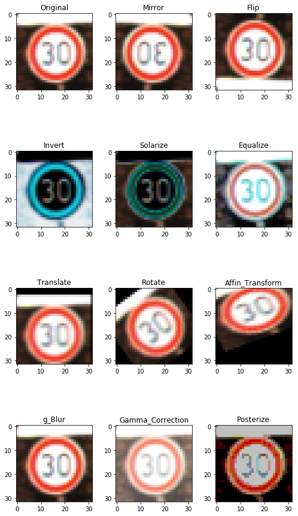

```python
'''
Visualize different image effects.

'''


fig, axs= plt.subplots(4,3, figsize=(32,32))
fig.set_size_inches((8.27, 15))
fig.subplots_adjust(hspace = 0.8, wspace =  0.3)
axs = axs.ravel()

image_effects=['Original','Mirror','Flip','Invert','Solarize','Equalize','Translate','Rotate','Affin_Transform','g_Blur','Gamma_Correction','Posterize']

for i,fx in enumerate(image_effects):
    axs[i].imshow(image_effect(X_train[3000],image_effect=fx))
    axs[i].set_title(fx)


plt.show()
```

#### Image Augmentation Process

- Calculate an equal target count for all image classes
- For each Image class in the dataset augment the class set with new images using Random image from the original set and applying randome effect until total count for the class reach the target count calculated in step 1.
- Concatenate the new generated data set to the original set.

```python
#Dictionary used to collect frequency of each applied effect during augmentation process
augmentation_stats={'Translate':0,'Rotate':0,'Affin_Transform':0,'Blur':0,'Gamma_Correction':0}


unique_ids,sign_counts=np.unique(y_train, return_counts=True)

#The final count of image labels = Max frequency + 2000`
#to avoid data set that result in opinionated model
traget_max_count=np.amax(sign_counts)


X_train_augmented = np.array(np.zeros((1, 32, 32, 3)))
y_train_augmented = np.array([0])

print("Ids   Cnt  Target   Aug_Stats")
print("===   ===  ======   ==========")

for sign_id in unique_ids:
    X_train_by_classId = X_train[y_train == sign_id, ...]

    batch_images = []


    #Count of augmented images to reach target_max_count
    aug_count=traget_max_count - len(X_train_by_classId)

    for i in range(aug_count):
            batch_images.append(image_effect(X_train_by_classId[random.randint(0,len(X_train_by_classId)-1)]))

    if len(batch_images) > 0:
        aug_images  = np.concatenate((X_train_by_classId, batch_images), axis=0)

    aug_labels  = np.full(len(aug_images), sign_id, dtype='uint8')


    X_train_augmented   = np.concatenate((X_train_augmented, aug_images), axis=0)
    y_train_augmented = np.concatenate((y_train_augmented, aug_labels), axis=0)


    print("{}    {}   {}    {}".format(sign_id,len(X_train_by_classId),len(aug_images),augmentation_stats))


X_train_augmented = X_train_augmented/255
```

```
Ids   Cnt  Target   Aug_Stats
===   ===  ======   ==========
0    180   2010    {'Affin_Transform': 352, 'Translate': 346, 'Gamma_Correction': 377, 'Blur': 365, 'Rotate': 390}
1    1980   2010    {'Affin_Transform': 357, 'Translate': 351, 'Gamma_Correction': 384, 'Blur': 373, 'Rotate': 395}
2    2010   2010    {'Affin_Transform': 357, 'Translate': 351, 'Gamma_Correction': 384, 'Blur': 373, 'Rotate': 395}
3    1260   2010    {'Affin_Transform': 504, 'Translate': 505, 'Gamma_Correction': 534, 'Blur': 514, 'Rotate': 553}
4    1770   2010    {'Affin_Transform': 556, 'Translate': 559, 'Gamma_Correction': 583, 'Blur': 564, 'Rotate': 588}
5    1650   2010    {'Affin_Transform': 617, 'Translate': 625, 'Gamma_Correction': 657, 'Blur': 648, 'Rotate': 663}
6    360   2010    {'Affin_Transform': 948, 'Translate': 941, 'Gamma_Correction': 981, 'Blur': 994, 'Rotate': 996}
7    1290   2010    {'Affin_Transform': 1114, 'Translate': 1087, 'Gamma_Correction': 1119, 'Blur': 1145, 'Rotate': 1115}
8    1260   2010    {'Affin_Transform': 1280, 'Translate': 1232, 'Gamma_Correction': 1250, 'Blur': 1297, 'Rotate': 1271}
9    1320   2010    {'Affin_Transform': 1408, 'Translate': 1369, 'Gamma_Correction': 1394, 'Blur': 1442, 'Rotate': 1407}
10    1800   2010    {'Affin_Transform': 1440, 'Translate': 1420, 'Gamma_Correction': 1444, 'Blur': 1472, 'Rotate': 1454}
11    1170   2010    {'Affin_Transform': 1600, 'Translate': 1598, 'Gamma_Correction': 1608, 'Blur': 1646, 'Rotate': 1618}
12    1890   2010    {'Affin_Transform': 1619, 'Translate': 1615, 'Gamma_Correction': 1633, 'Blur': 1672, 'Rotate': 1651}
```

[output cut: 30 more lines]

```
{'Affin_Transform': 10250, 'Translate': 10285, 'Gamma_Correction': 10350, 'Blur': 10401, 'Rotate': 10345}
```

```
<Container object of 5 artists>
```

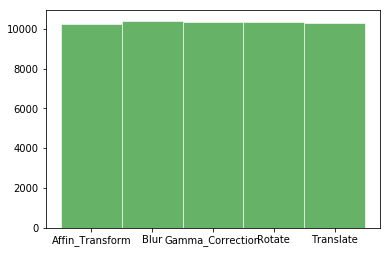

```python
#Print frequency of each applied effect during augmentation process
print(augmentation_stats)

plt.bar(augmentation_stats.keys(),augmentation_stats.values(),width=1.0,color='g',alpha=0.6,edgecolor='white')
```

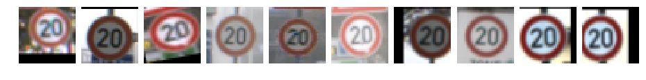

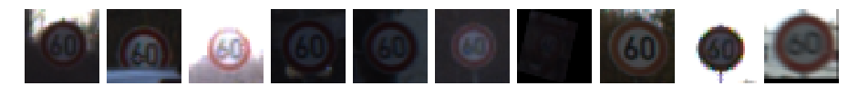

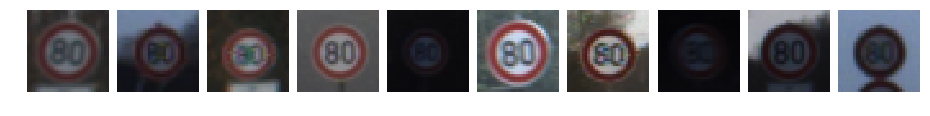

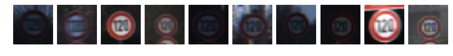

[figure not shown]

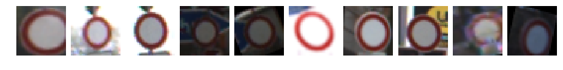

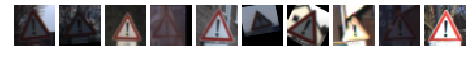

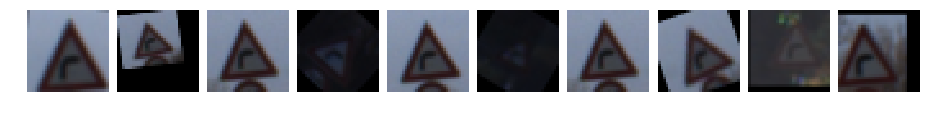

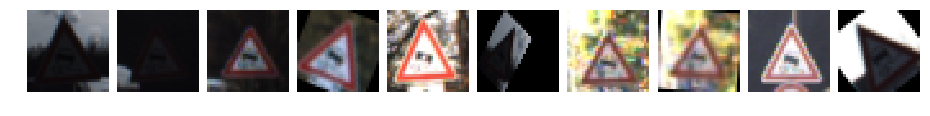

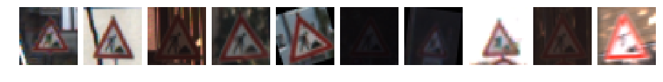

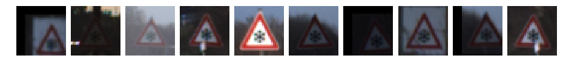

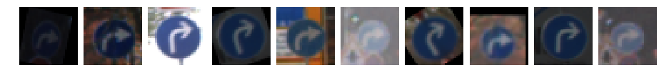

[4 more figures not shown]

```python
#show  random Images from the data set filter for a specific class
#Let's explore samples from each class
showSampleImage(X_train_augmented,y_train_augmented,10,filter_class=0,randomize=True,hSize=8,wSize=8,n_row=1,image_title=False)
showSampleImage(X_train_augmented,y_train_augmented,10,filter_class=3,randomize=True,hSize=8,wSize=8,n_row=1,image_title=False)
showSampleImage(X_train_augmented,y_train_augmented,10,filter_class=5,randomize=True,hSize=8,wSize=8,n_row=1,image_title=False)
showSampleImage(X_train_augmented,y_train_augmented,10,filter_class=8,randomize=True,hSize=8,wSize=8,n_row=1,image_title=False)
showSampleImage(X_train_augmented,y_train_augmented,10,filter_class=10,randomize=True,hSize=8,wSize=8,n_row=1,image_title=False)

showSampleImage(X_train_augmented,y_train_augmented,10,filter_class=15,randomize=True,hSize=8,wSize=8,n_row=1,image_title=False)
showSampleImage(X_train_augmented,y_train_augmented,10,filter_class=18,randomize=True,hSize=8,wSize=8,n_row=1,image_title=False)
showSampleImage(X_train_augmented,y_train_augmented,10,filter_class=20,randomize=True,hSize=8,wSize=8,n_row=1,image_title=False)
showSampleImage(X_train_augmented,y_train_augmented,10,filter_class=23,randomize=True,hSize=8,wSize=8,n_row=1,image_title=False)
showSampleImage(X_train_augmented,y_train_augmented,10,filter_class=25,randomize=True,hSize=8,wSize=8,n_row=1,image_title=False)

showSampleImage(X_train_augmented,y_train_augmented,10,filter_class=30,randomize=True,hSize=8,wSize=8,n_row=1,image_title=False)
showSampleImage(X_train_augmented,y_train_augmented,10,filter_class=33,randomize=True,hSize=8,wSize=8,n_row=1,image_title=False)
showSampleImage(X_train_augmented,y_train_augmented,10,filter_class=35,randomize=True,hSize=8,wSize=8,n_row=1,image_title=False)
showSampleImage(X_train_augmented,y_train_augmented,10,filter_class=38,randomize=True,hSize=8,wSize=8,n_row=1,image_title=False)
showSampleImage(X_train_augmented,y_train_augmented,10,filter_class=40,randomize=True,hSize=8,wSize=8,n_row=1,image_title=False)
showSampleImage(X_train_augmented,y_train_augmented,10,filter_class=42,randomize=True,hSize=8,wSize=8,n_row=1,image_title=False)
```

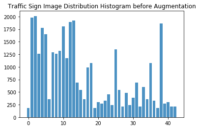

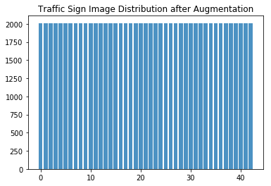

```python
# Visualize frequency of class IDs in the original data set
cls_id, count = np.unique(y_train, return_counts=True)
plt.figure(1)
plt.bar(cls_id, count, alpha=0.8)
plt.title('Traffic Sign Image Distribution Histogram before Augmentation')

# Visualize frequency of sign classes in the augment data set
cls_id, count = np.unique(y_train_augmented, return_counts=True)
plt.figure(2)
plt.bar(cls_id, count, alpha=0.8)
plt.title('Traffic Sign Image Distribution after Augmentation')



plt.show()
```

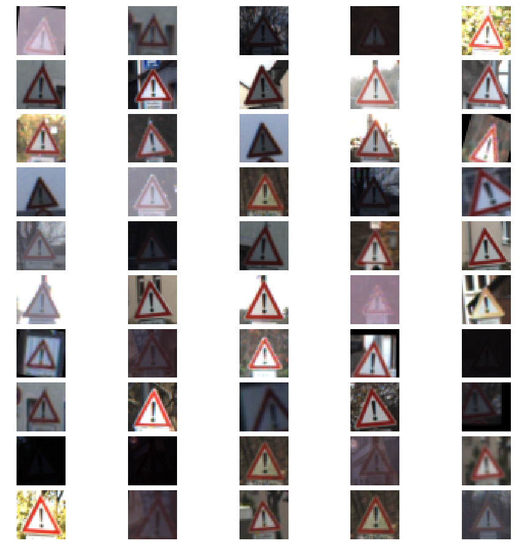

```python
X_train = X_train_augmented
y_train = y_train_augmented

#show  random Images from the data set filter for a specific class
#Let's explore samples from each class
showSampleImage(X_train,y_train,50,filter_class=18,randomize=True,image_title=False)
```

## Step 2: Design and Test a Model Architecture

### Pre-process the Data Set (normalization, grayscale, etc.)

```python
### Preprocess the data here. It is required to normalize the data. Other preprocessing steps could include
### converting to grayscale, etc.
### Feel free to use as many code cells as needed.


def conv2GrayScale(X_train):
    return np.sum(X_train/3, axis=3, keepdims=True)


# Converting to grayscale
X_train_rgb = X_train
X_train_gry = conv2GrayScale(X_train)

X_test_rgb = X_test
X_test_gry = conv2GrayScale(X_test)

X_validation_rgb = X_validation
X_validation_gry = conv2GrayScale(X_validation)

print('RGB shape:', X_train_rgb.shape)
print('Grayscale shape:', X_train_gry.shape)


X_train = X_train_gry
X_test = X_test_gry
X_validation = X_validation_gry

# TODO!! Visualize graysacle
```

```
RGB shape: (86431, 32, 32, 3)
Grayscale shape: (86431, 32, 32, 1)
```

```python
from sklearn.utils import shuffle

X_train, y_train = shuffle(X_train, y_train)
```

```python
## Normalize the train and test datasets to (-1,1)

def normalize(X_train):
    return (X_train-128)/128

X_train_normalized = normalize(X_train)
X_test_normalized = normalize(X_test)
X_validation_normalized = normalize(X_validation)

#X_train_normalized = (X_train-128)/128
#X_test_normalized = (X_test-128)/128

print(np.mean(X_train_normalized))
print(np.mean(X_test_normalized))
print(np.mean(X_validation_normalized))
```

```
-0.9974813881028776
-0.3582151534281105
-0.3472154111278294
```

```
Original shape: (86431, 32, 32, 1)
Normalized shape: (86431, 32, 32, 1)
```

[figure not shown]

```python
print("Original shape:", X_train.shape)
print("Normalized shape:", X_train_normalized.shape)
fig, axs = plt.subplots(1,2, figsize=(10, 3))
axs = axs.ravel()

axs[0].axis('off')
axs[0].set_title('normalized')
axs[0].imshow(X_train_normalized[0].squeeze(), cmap='gray')

axs[1].axis('off')
axs[1].set_title('original')
axs[1].imshow(X_train_rgb[0])
```

### Architecture

**Layer 1: Convolutional.** Input = 32x32x1. Output = 28x28x6. Padding: VALID

**Activation.** RELU Activation

**Pooling.** Pooling. Input = 28x28x6. Output = 14x14x6.

**Layer 2: Convolutional.** Output = 10x10x16. Padding: VALID

**Activation.** RELU Activation

**Pooling.** Input = 10x10x16. Output = 5x5x16.

**Flatten.** Input = 5x5x16. Output = 400. Flatten the output shape of the final pooling layer such that it's 1D instead of 3D. The easiest way to do is by using `tf.contrib.layers.flatten`

**Layer 3: Fully Connected.** Input = 400. Output = 120.

**Activation.** Activation: RELU.

**Layer 4: Fully Connected.** Fully Connected. Input = 120. Output = 84.

**Activation.** Activation: RELU.

**Layer 5: Fully Connected (Logits).** Fully Connected. Input = 84. Output = 43

## Setup TensorFlow

The `EPOCH` and `BATCH_SIZE` values affect the training speed and model accuracy.

You do not need to modify this section.

```python
#Enhanced TsNet
# Implemented:
#    - DropOut
# Todo:
#    - L2 Regularization
def TsNetEx(x):
 with tf.device('/cpu:0'):
    # Arguments used for tf.truncated_normal, randomly defines variables for the weights and biases for each layer
    mu = 0
    sigma = 0.1

    # SOLUTION: Layer 1: Convolutional. Input = 32x32x1. Output = 28x28x6.
    conv1_W = tf.Variable(tf.truncated_normal(shape=(5, 5, 1, 6), mean = mu, stddev = sigma))
    conv1_b = tf.Variable(tf.zeros(6))
    conv1   = tf.nn.conv2d(x, conv1_W, strides=[1, 1, 1, 1], padding='VALID') + conv1_b

    # SOLUTION: Activation.
    conv1 = tf.nn.relu(conv1)

    # SOLUTION: Pooling. Input = 28x28x6. Output = 14x14x6.
    conv1 = tf.nn.max_pool(conv1, ksize=[1, 2, 2, 1], strides=[1, 2, 2, 1], padding='VALID')

    # SOLUTION: Layer 2: Convolutional. Output = 10x10x16.
    conv2_W = tf.Variable(tf.truncated_normal(shape=(5, 5, 6, 16), mean = mu, stddev = sigma))
    conv2_b = tf.Variable(tf.zeros(16))
    conv2   = tf.nn.conv2d(conv1, conv2_W, strides=[1, 1, 1, 1], padding='VALID') + conv2_b

    # SOLUTION: Activation.
    conv2 = tf.nn.relu(conv2)

    # SOLUTION: Pooling. Input = 10x10x16. Output = 5x5x16.
    conv2 = tf.nn.max_pool(conv2, ksize=[1, 2, 2, 1], strides=[1, 2, 2, 1], padding='VALID')

    # SOLUTION: Flatten. Input = 5x5x16. Output = 400.
    fc0   = flatten(conv2)

    # SOLUTION: Layer 3: Fully Connected. Input = 400. Output = 120.
    fc1_W = tf.Variable(tf.truncated_normal(shape=(400, 120), mean = mu, stddev = sigma))
    fc1_b = tf.Variable(tf.zeros(120))
    fc1   = tf.matmul(fc0, fc1_W) + fc1_b

    # SOLUTION: Activation.
    fc1    = tf.nn.relu(fc1)

    # SOLUTION: Layer 4: Fully Connected. Input = 120. Output = 84.
    fc2_W  = tf.Variable(tf.truncated_normal(shape=(120, 84), mean = mu, stddev = sigma))
    fc2_b  = tf.Variable(tf.zeros(84))
    fc2    = tf.matmul(fc1, fc2_W) + fc2_b

    # SOLUTION: Activation.
    fc2    = tf.nn.relu(fc2)

     # Dropout
    fc2 = tf.nn.dropout(fc2, keep_prob)

    # SOLUTION: Layer 5: Fully Connected. Input = 84. Output = 10.
    fc3_W  = tf.Variable(tf.truncated_normal(shape=(84, 43), mean = mu, stddev = sigma))
    fc3_b  = tf.Variable(tf.zeros(43))
    logits = tf.add(tf.matmul(fc2, fc3_W), fc3_b)

    return logits, conv1, conv2
```

## Features and Labels

`x` is a placeholder for a batch of input images. `y` is a placeholder for a batch of output labels.

You do not need to modify this section.

```python
#Clears the default graph stack and resets the global default graph.
tf.reset_default_graph()

x = tf.placeholder(tf.float32, (None, 32, 32, 1))
y = tf.placeholder(tf.int32, (None))

# To Control DropOut Rate
keep_prob = tf.placeholder(tf.float32)

#Returns a one-hot tensor.
one_hot_y = tf.one_hot(y, 43)


print('done')
```

```
done
```

### Train, Validate and Test the Model

A validation set can be used to assess how well the model is performing. A low accuracy on the training and validation sets imply underfitting. A high accuracy on the training set but low accuracy on the validation set implies overfitting.

## Training Pipeline

You do not need to modify this section.

```python
### Train your model here.
### Calculate and report the accuracy on the training and validation set.
### Once a final model architecture is selected,
### the accuracy on the test set should be calculated and reported as well.
### Feel free to use as many code cells as needed.
```

```python
EPOCHS = 200
BATCH_SIZE = 128
rate= 0.001


logits,conv1,conv2 = TsNetEx(x)


#Distance between the SoftMaX(Y) and one_hot encoded labels.
cross_entropy = tf.nn.softmax_cross_entropy_with_logits(labels=one_hot_y, logits=logits)

#Average cross Entropy across the entire training set
loss_operation = tf.reduce_mean(cross_entropy)

#Training weights and biases
#optimizer = tf.train.AdamOptimizer(learning_rate = rate)
optimizer = tf.train.AdamOptimizer()
training_operation = optimizer.minimize(loss_operation)
```

## Model Evaluation

Evaluate how well the loss and accuracy of the model for a given dataset.

You do not need to modify this section.

```python
correct_prediction = tf.equal(tf.argmax(logits, 1), tf.argmax(one_hot_y, 1))
accuracy_operation = tf.reduce_mean(tf.cast(correct_prediction, tf.float32))
saver = tf.train.Saver()

def evaluate(X_data, y_data):
    num_examples = len(X_data)
    total_accuracy = 0
    sess = tf.get_default_session()
    for offset in range(0, num_examples, BATCH_SIZE):
        batch_x, batch_y = X_data[offset:offset+BATCH_SIZE], y_data[offset:offset+BATCH_SIZE]
        accuracy = sess.run(accuracy_operation, feed_dict={x: batch_x, y: batch_y, keep_prob: 1.0})
        #accuracy = sess.run(accuracy_operation, feed_dict={x: batch_x, y: batch_y})
        total_accuracy += (accuracy * len(batch_x))
    return total_accuracy / num_examples

print('done')
```

```
done
```

## Train the Model

Run the training data through the training pipeline to train the model.

Before each epoch, shuffle the training set.

After each epoch, measure the loss and accuracy of the validation set.

Save the model after training.

You do not need to modify this section.

### Question 2.3. Describe how you trained your model. The discussion can include the type of optimizer, the batch size, number of epochs and any hyperparameters such as learning rate.

- Optimizer : AdamOptimizer
- Hyper Parameters :
  - EPOCHS = 200 OtherValuesUsed={10, 25, 50, 100, 125, 150, 200, 250, 275, 300, 500, 1000}
  - BATCH_SIZE = 128 OtherValuesUsed={100,128}
  - Learning Rate= 0.001 OtherValuesUsed={0.0007, 0.0008, 0.0009, 0.001, 0.002, 0.005}
  - DropOut = 0.5 OtherValuesUsed={0.5, 0.6, 0.7}
  - mu = 0
  - sigma = 0.1

```python
.import time
#from tqdm import tqdm





# Measurements use for graphing loss and accuracy
batches = []
loss_batch = []
train_acc_batch = []
valid_acc_batch = []
epoch_progress = []
batch_progress=0
with tf.Session() as sess:
    sess.run(tf.global_variables_initializer())
    num_examples = len(X_train)

    start = time.time()
    print("Training...")
    print()
    for i in range(EPOCHS):


        X_train, y_train = shuffle(X_train, y_train)
        for offset in range(0, num_examples, BATCH_SIZE):
            end = offset + BATCH_SIZE
            batch_x, batch_y = X_train[offset:end], y_train[offset:end]
            _, loss=sess.run([training_operation,loss_operation], feed_dict={x: batch_x, y: batch_y, keep_prob: 0.5})

            #_, loss=sess.run([training_operation,loss_operation], feed_dict={x: batch_x, y: batch_y})


            loss_batch.append(loss)
            batches.append(batch_progress)
            batch_progress+=BATCH_SIZE

        training_accuracy = evaluate(X_train,y_train)
        train_acc_batch.append(training_accuracy)

        validation_accuracy = evaluate(X_validation, y_validation)
        valid_acc_batch.append(validation_accuracy)

        epoch_progress.append(i)
        print("EPOCH {} ".format((i+1)))
        print("...Training Accuracy = {:.3f} ...Validation Accuracy = {:.3f} ...Loss = {:.3f}".format(training_accuracy,validation_accuracy,loss))

    end = time.time()
    print("Training Time :"+str((end - start)/60)+" Minutes")
    saver.save(sess, './tsnet')
    print("Model saved")
```

```
Training...

EPOCH 1
...Training Accuracy = 0.677 ...Validation Accuracy = 0.759 ...Loss = 1.664
EPOCH 2
...Training Accuracy = 0.773 ...Validation Accuracy = 0.808 ...Loss = 1.091
EPOCH 3
...Training Accuracy = 0.803 ...Validation Accuracy = 0.841 ...Loss = 0.744
EPOCH 4
...Training Accuracy = 0.828 ...Validation Accuracy = 0.878 ...Loss = 0.976
EPOCH 5
...Training Accuracy = 0.842 ...Validation Accuracy = 0.900 ...Loss = 0.402
EPOCH 6
...Training Accuracy = 0.852 ...Validation Accuracy = 0.895 ...Loss = 0.511
EPOCH 7
...Training Accuracy = 0.866 ...Validation Accuracy = 0.898 ...Loss = 0.598
EPOCH 8
...Training Accuracy = 0.873 ...Validation Accuracy = 0.912 ...Loss = 0.686
EPOCH 9
...Training Accuracy = 0.880 ...Validation Accuracy = 0.923 ...Loss = 0.566
EPOCH 10
...Training Accuracy = 0.883 ...Validation Accuracy = 0.900 ...Loss = 0.724
EPOCH 11
...Training Accuracy = 0.892 ...Validation Accuracy = 0.918 ...Loss = 1.104
EPOCH 12
...Training Accuracy = 0.898 ...Validation Accuracy = 0.922 ...Loss = 0.402
EPOCH 13
...Training Accuracy = 0.902 ...Validation Accuracy = 0.919 ...Loss = 0.658
EPOCH 14
...Training Accuracy = 0.904 ...Validation Accuracy = 0.916 ...Loss = 0.617
EPOCH 15
...Training Accuracy = 0.909 ...Validation Accuracy = 0.916 ...Loss = 0.254
EPOCH 16
...Training Accuracy = 0.913 ...Validation Accuracy = 0.915 ...Loss = 0.314
EPOCH 17
...Training Accuracy = 0.915 ...Validation Accuracy = 0.902 ...Loss = 0.539
EPOCH 18
...Training Accuracy = 0.922 ...Validation Accuracy = 0.921 ...Loss = 0.603
EPOCH 19
...Training Accuracy = 0.922 ...Validation Accuracy = 0.925 ...Loss = 0.422
```

[output cut: 349 more lines]

```
...Training Accuracy = 0.993 ...Validation Accuracy = 0.937 ...Loss = 0.069
EPOCH 195
...Training Accuracy = 0.992 ...Validation Accuracy = 0.944 ...Loss = 0.193
EPOCH 196
...Training Accuracy = 0.993 ...Validation Accuracy = 0.937 ...Loss = 0.087
EPOCH 197
...Training Accuracy = 0.993 ...Validation Accuracy = 0.947 ...Loss = 0.006
EPOCH 198
...Training Accuracy = 0.995 ...Validation Accuracy = 0.943 ...Loss = 0.169
EPOCH 199
...Training Accuracy = 0.994 ...Validation Accuracy = 0.947 ...Loss = 0.041
EPOCH 200
...Training Accuracy = 0.993 ...Validation Accuracy = 0.951 ...Loss = 0.018
Training Time :118.11126843690872 Minutes
Model saved
```

## Training Log

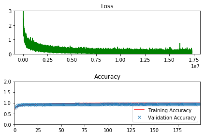

```python
    #Visualizing loss across all data set during all EPOCHS
    loss_plot = plt.subplot(211)
    loss_plot.set_title('Loss')
    loss_plot.plot(batches,loss_batch,'g')
    loss_plot.set_ylim([0.0001,3])

    #Comparing accuracy for validation and training data during each EPOCH
    acc_plot = plt.subplot(212)
    acc_plot.set_title('Accuracy')
    acc_plot.plot(epoch_progress, train_acc_batch, 'r', label='Training Accuracy')
    acc_plot.plot(epoch_progress, valid_acc_batch, 'x', label='Validation Accuracy')
    acc_plot.set_ylim([0, 2.0])
    acc_plot.set_xlim([epoch_progress[0], epoch_progress[-1]])
    acc_plot.legend(loc=4)
    plt.tight_layout()
    plt.show()
```

### Question 2.4. Describe the approach taken for finding a solution and getting the validation set accuracy to be at least 0.93. Include in the discussion the results on the training, validation and test sets and where in the code these were calculated. Your approach may have been an iterative process, in which case, outline the steps you took to get to the final solution and why you chose those steps. Perhaps your solution involved an already well known implementation or architecture. In this case, discuss why you think the architecture is suitable for the current problem.

- 1st Approach :

  ```
     * Processing : CPU0 I7-4930k @ 3.40GHZ (My GPU only support CUDA 2 while Tensor flow require CUDA 3 at minimum)
     * Model : Used Default LeNet Model with minor changes to fit new Input and ouput Labels
     * Training DataSet: Used the Default data without augmentation
     * Sample Results :
            EPOCH 100, BATCH_SIZE=128, rate=0.001, Kp=0.0 Accuracy on Extra Test Image : 0.083333
            EPOCH 50, BATCH_SIZE=128, rate=0.0009, Kp=0.0 Accuracy on Extra Test Image : 0.0000
            EPOCH 200, BATCH_SIZE=128, rate=0.0009, Kp=0.0 Accuracy on Extra Test Image : 0.0000
            EPOCH 50 BATCH_SIZE=128 rate=0.001   Validation Accuracy on Extra Test Image : 0.252
            EPOCH 100 BATCH_SIZE=128 rate=0.0009 Validation Accuracy on Extra Test Image : 0.222
  ```

- 2nd Approach :

  ```
    * Processing :  Amazon EC2 GPU Instance G2
    * Model : Introduced DropOut
              Increased Output width at the Convolutional layers
    * Training DataSet: still no Augmenation
    * Best Result:
            EPOCH 200, BATCH_SIZE=128, rate=0.0009, KP=0.5  Validation Accuracy = 0.8, Accuracy on Extra Test Images = 0.5
  ```

Notes:

```
* Learning rate and EPOCH# had the biggest impact on the model accuracy.
* Setting large EPOCH number tends to yield a highly overfitted model that had very low accuracy against extra test images.
* Data Set augmenation helped me with increasing model accuracy from 50% to almost 90%
```

## Evaluate the Model

```python
with tf.Session() as sess:
    saver.restore(sess, tf.train.latest_checkpoint('.'))

    print("\n  Training set accuracy = {:.3f}".format(evaluate(X_train, y_train)))
    print("Validation set accuracy = {:.3f}".format(evaluate(X_validation, y_validation)))
    print("      Test set accuracy = {:.3f}".format(evaluate(X_test, y_test)))
```

```
INFO:tensorflow:Restoring parameters from .\tsnet

  Training set accuracy = 0.993
Validation set accuracy = 0.951
      Test set accuracy = 0.916
```

## Step 3: Test a Model on New Images

To give yourself more insight into how your model is working, download at least five pictures of German traffic signs from the web and use your model to predict the traffic sign type.

You may find `signnames.csv` useful as it contains mappings from the class id (integer) to the actual sign name.

### Load and Output the Images

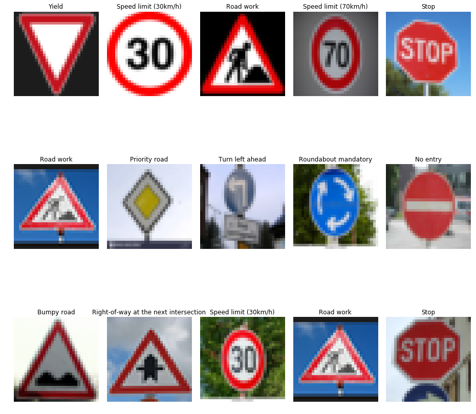

```python
def load_extra_images(path):
    file_list = os.listdir(path)
    #print(file_list)
    images=[]
    labels=[]
    for file in file_list:
        img=cv2.imread(path+'/'+file)
        #img=mpimg.imread(path+'/'+file)
        #img=tf.image.resize_images(img, [32, 32])
        img=imresize(img, [32,32])
        img = cv2.cvtColor(img, cv2.COLOR_BGR2RGB)
        images.append(img)

        #images.append(img)
        labels.append(int(file.split('_')[1].split('.')[0]))
        #imgplot = plt.imshow(img)
        #plt.show()
        #print(int(file.split('_')[1].split('.')[0]))
    return images,labels


X_Extra=[]
y_extra=[]
X_Extra,y_extra=load_extra_images('./test_images')


showSampleImage(X_Extra,
                y_extra,
                len(X_Extra),
                randomize=False,
                filter_class=None)
```

```
(15, 32, 32, 3)
(15, 32, 32, 1)
1
```

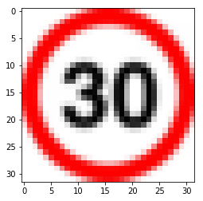

```python
#Normalize Extra testing set

X_Extra=np.asarray(X_Extra)
X_Extra_grey = conv2GrayScale(X_Extra)
X_Extra_normalized = normalize(X_Extra_grey)
print(X_Extra.shape)
print(X_Extra_normalized.shape)

plt.imshow(X_Extra[1],cmap='gray')
print(y_extra[1])
```

### Predict the Sign Type for Each Image

```
INFO:tensorflow:Restoring parameters from .\tsnet
```

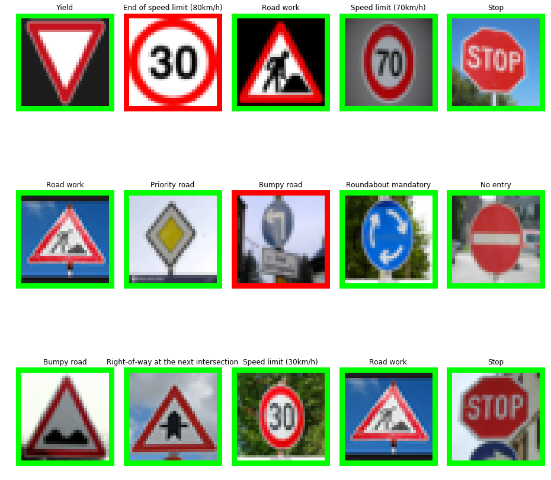

```python
### Run the predictions here and use the model to output the prediction for each image.
### Make sure to pre-process the images with the same pre-processing pipeline used earlier.
### Feel free to use as many code cells as needed.

with tf.Session() as sess:
    saver.restore(sess, tf.train.latest_checkpoint('.'))
    result=sess.run(logits, feed_dict={x: X_Extra_normalized, y: y_extra, keep_prob: 1.0})
    predicted_label = np.argmax(result, axis = 1)
    #print(predicted_label)

showSampleImage(X_Extra,predicted_label, len(X_Extra),randomize=False,filter_class=None,actual_title_list=y_extra)


#legend
# Green Border ... Correct Predictions :)
# Red Border ... Incorrect Predictions :(
```

### Analyze Performance

```python
### Calculate the accuracy for these 5 new images.
### For example, if the model predicted 1 out of 5 signs correctly, it's 20% accurate on these new images.

with tf.Session() as sess:
    saver.restore(sess, tf.train.latest_checkpoint('.'))
    #print("\n  Training set accuracy = {:.3f}".format(evaluate(X_train[1:2], y_train[1:2])))
    print("Extra Test set accuracy = {:.3f} %".format(evaluate(X_Extra_normalized, y_extra)*100))
```

```
INFO:tensorflow:Restoring parameters from .\tsnet
Extra Test set accuracy = 86.667 %
```

### Question 3.1. Choose five German traffic signs found on the web and provide them in the report. For each image, discuss what quality or qualities might be difficult to classify.

#### Question 3.2. Discuss the model's predictions on these new traffic signs and compare the results to predicting on the test set. At a minimum, discuss what the predictions were, the accuracy on these new predictions, and compare the accuracy to the accuracy on the test set (OPTIONAL: Discuss the results in more detail as described in the "Stand Out Suggestions" part of the rubric).

The model prediction results was satisfactory on these new extra traffic signs (86.66%) and not far from the model accuracy on the test images (91% accuracy).

### Output Top 5 Softmax Probabilities For Each Image Found on the Web

For each of the new images, print out the model's softmax probabilities to show the **certainty** of the model's predictions (limit the output to the top 5 probabilities for each image). [`tf.nn.top_k`](https://www.tensorflow.org/versions/r0.12/api_docs/python/nn.html#top_k) could prove helpful here.

The example below demonstrates how tf.nn.top_k can be used to find the top k predictions for each image.

`tf.nn.top_k` will return the values and indices (class ids) of the top k predictions. So if k=3, for each sign, it'll return the 3 largest probabilities (out of a possible 43) and the correspoding class ids.

Take this numpy array as an example. The values in the array represent predictions. The array contains softmax probabilities for five candidate images with six possible classes. `tf.nn.top_k` is used to choose the three classes with the highest probability:

```
# (5, 6) array
a = np.array([[ 0.24879643,  0.07032244,  0.12641572,  0.34763842,  0.07893497,
         0.12789202],
       [ 0.28086119,  0.27569815,  0.08594638,  0.0178669 ,  0.18063401,
         0.15899337],
       [ 0.26076848,  0.23664738,  0.08020603,  0.07001922,  0.1134371 ,
         0.23892179],
       [ 0.11943333,  0.29198961,  0.02605103,  0.26234032,  0.1351348 ,
         0.16505091],
       [ 0.09561176,  0.34396535,  0.0643941 ,  0.16240774,  0.24206137,
         0.09155967]])
```

Running it through `sess.run(tf.nn.top_k(tf.constant(a), k=3))` produces:

```
TopKV2(values=array([[ 0.34763842,  0.24879643,  0.12789202],
       [ 0.28086119,  0.27569815,  0.18063401],
       [ 0.26076848,  0.23892179,  0.23664738],
       [ 0.29198961,  0.26234032,  0.16505091],
       [ 0.34396535,  0.24206137,  0.16240774]]), indices=array([[3, 0, 5],
       [0, 1, 4],
       [0, 5, 1],
       [1, 3, 5],
       [1, 4, 3]], dtype=int32))
```

Looking just at the first row we get `[ 0.34763842, 0.24879643, 0.12789202]`, you can confirm these are the 3 largest probabilities in `a`. You'll also notice `[3, 0, 5]` are the corresponding indices.

```python
### Print out the top five softmax probabilities for the predictions on the German traffic sign images found on the web.
### Feel free to use as many code cells as needed.



logits_k=tf.placeholder(tf.float32)
softmax = tf.nn.softmax(logits_k)
with tf.Session() as sess:
    saver.restore(sess, tf.train.latest_checkpoint('.'))
    #Finds values and indices of the k largest entries for the last dimension.
    values, indices = sess.run(tf.nn.top_k(result, k=5))
    print('-------------------------------------------------------------------------------------------')
    print(' label indices (classes) for all 15 images')
    print(indices)
    print('-------------------------------------------------------------------------------------------')
    print(' Predicted Probabilities for all 15 images')
    print(values)

    softmax_prob = sess.run(softmax, feed_dict={logits_k: values})
    print('-------------------------------------------------------------------------------------------')
    print(' Softmax of Predicted Probabilities for all 15 images')
    print(softmax_prob)

for i in range(len(y_extra)):
    print('-------------------------------------------------------------------------------------------')
    print('**** Image {} :  '.format(i))
    #plt.imshow(imresize(X_Extra[i], [16,16]))
    #plt.show()
    print('                 Actual_Class    == ({})'.format(getSignNameById(str(y_extra[i]))))
    print('                 Predicted_Class == ({})'.format(getSignNameById(str(predicted_label[i]))))
    if y_extra[i]==predicted_label[i]:
            print('                       --> The Predicted label match actual class (Match) ')
    else:
            print('                       --> The Predicted label did NOT match actual class (No Match) ')

    print('                 Top 5 Prediction Probabilities : ')

    y_sorted = [indices[i] for _,x in sorted(zip(softmax_prob[i],indices[i]))]
    softmax_sorted=np.sort(softmax_prob[i])[::-1]
    for index in range(len(y_sorted[0])):
        print('                            {}. : {} , probability: {} %'.format(index,getSignNameById(str(y_sorted[0][index])),softmax_sorted[index]*100))

    #print(y_sorted[0])
```

```
INFO:tensorflow:Restoring parameters from .\tsnet
-------------------------------------------------------------------------------------------
 label indices (classes) for all 15 images
[[13 12 38 34 29]
 [ 6  5  7  1  8]
 [25 30 20 23 22]
 [ 4  8 26 31  7]
 [14 17  8 34 38]
 [25 38 30 20 22]
 [12 41 15 18 42]
 [22 38 14 15 13]
 [40  1 39  7  0]
 [17 10 34 40 14]
 [22 29 38 26 28]
 [11 30 21 40 25]
 [ 1  4  0  2  8]
 [25 38 30 20 22]
 [14 38 34 15  4]]
-------------------------------------------------------------------------------------------
 Predicted Probabilities for all 15 images
[[  33.681328    20.78622     -1.4781467  -35.147373   -35.43019  ]
 [  13.128907   -11.306796   -11.487299   -12.219127   -42.24548  ]
 [ 131.42723     12.052686   -53.929985  -118.23535   -150.98221  ]
 [  34.347424   -35.989204   -49.570522   -56.95614    -60.018864 ]
 [  30.755413     1.4582164   -6.2949686   -8.302131   -20.008337 ]
 [  72.30081     -8.364271   -23.171984   -36.697723   -60.081665 ]
 [  14.931318   -33.3814     -36.077507   -41.974113   -43.969337 ]
 [  10.635921     4.8857756    3.4924083   -1.491667    -4.561928 ]
 [  14.358021     3.9154408    1.7060323   -3.2812707   -6.0160785]
 [  77.43073      0.7437843  -49.01974    -56.496643   -62.08064  ]
 [  84.23002     39.563953   -32.833813   -41.665638   -41.874207 ]
 [ 200.01268    115.358574    46.932117   -63.342003  -133.85388  ]
 [ 101.05747    -43.015163   -46.362335   -60.822945   -62.865356 ]
 [  72.30081     -8.364271   -23.171984   -36.697723   -60.081665 ]
 [  21.47879     -9.026398   -16.024107   -20.05142    -23.461004 ]]
-------------------------------------------------------------------------------------------
 Softmax of Predicted Probabilities for all 15 images
[[9.9999750e-01 2.5102963e-06 5.3756830e-16 1.2825438e-30 9.6660186e-31]
 [1.0000000e+00 2.4417933e-11 2.0385299e-11 9.8059286e-12 8.9373710e-25]
 [1.0000000e+00 0.0000000e+00 0.0000000e+00 0.0000000e+00 0.0000000e+00]
```

[output cut: 162 more lines]

```
                            1. : Keep right , probability: 9.281085369902231e-34 %
                            2. : Beware of ice/snow , probability: 0.0 %
                            3. : Dangerous curve to the right , probability: 0.0 %
                            4. : Bumpy road , probability: 0.0 %
-------------------------------------------------------------------------------------------
**** Image 14 :
                 Actual_Class    == (Stop)
                 Predicted_Class == (Stop)
                       --> The Predicted label match actual class (Match)
                 Top 5 Prediction Probabilities :
                            0. : Stop , probability: 100.0 %
                            1. : Keep right , probability: 5.646316205386304e-12 %
                            2. : Turn left ahead , probability: 5.160572053948466e-15 %
                            3. : No vehicles , probability: 9.197248557024244e-17 %
                            4. : Speed limit (70km/h) , probability: 3.0401456294866656e-18 %
```

### Question 3.3. Describe how certain the model is when predicting on each of the five new images by looking at the softmax probabilities for each prediction. Provide the top 5 softmax probabilities for each image along with the sign type of each probability. (OPTIONAL: as described in the "Stand Out Suggestions" part of the rubric, visualizations can also be provided such as bar charts)

## The model had a high accuracy with detecting images that is very similar to the original dataset. However image augementation helped with increased the model accuracy up to 90%

** Image 0 :

```
             * Actual_Class    == (Yield)
             * Predicted_Class == (Yield)
             * Top 5 Prediction Probabilities :
                        0. : Yield , probability: 99.99974966049194 %
                        1. : Priority road , probability: 0.0002510296326363459 %
                        2. : Keep right , probability: 5.3756829530463924e-14 %
                        3. : Turn left ahead , probability: 1.2825438001652313e-28 %
                        4. : Bicycles crossing , probability: 9.66601857675514e-29 %
```

** Image 1 :

```
             * Actual_Class    == (Speed limit (30km/h))
             * Predicted_Class == (End of speed limit (80km/h))
             * Top 5 Prediction Probabilities :
                        0. : End of speed limit (80km/h) , probability: 100.0 %
                        1. : Speed limit (80km/h) , probability: 2.4417932953380017e-09 %
                        2. : Speed limit (100km/h) , probability: 2.0385299351333153e-09 %
                        3. : Speed limit (30km/h) , probability: 9.805928638528805e-10 %
                        4. : Speed limit (120km/h) , probability: 8.937371029493639e-23 %
```

** Image 2 :

```
             * Actual_Class    == (Road work)
             * Predicted_Class == (Road work)
             * Top 5 Prediction Probabilities :
                        0. : Road work , probability: 100.0 %
                        1. : Beware of ice/snow , probability: 0.0 %
                        2. : Dangerous curve to the right , probability: 0.0 %
                        3. : Slippery road , probability: 0.0 %
                        4. : Bumpy road , probability: 0.0 %
```

** Image 3 :

```
             * Actual_Class    == (Speed limit (70km/h))
             * Predicted_Class == (Speed limit (70km/h))
             * Top 5 Prediction Probabilities :
                        0. : Speed limit (70km/h) , probability: 100.0 %
                        1. : Speed limit (120km/h) , probability: 2.839175737320734e-29 %
                        2. : Traffic signals , probability: 3.588386140803613e-35 %
                        3. : Wild animals crossing , probability: 0.0 %
                        4. : Speed limit (100km/h) , probability: 0.0 %
```

** Image 4 :

```
             * Actual_Class    == (Stop)
             * Predicted_Class == (Stop)
             * Top 5 Prediction Probabilities :
                        0. : Stop , probability: 100.0 %
                        1. : No entry , probability: 1.8896825293782116e-11 %
                        2. : Speed limit (120km/h) , probability: 8.113796099686927e-15 %
                        3. : Turn left ahead , probability: 1.0902443959879593e-15 %
                        4. : Keep right , probability: 8.986370217431401e-21 %
```

## Step 4 (Optional): Visualize the Neural Network's State with Test Images

### Question 4.1. Discuss the visual output of your trained network's feature maps. What characteristics did the neural network use to make classifications?

Visualizing the weights of different conv layers served as a great tool to understand how an input image preceived during the forward pass. in the below example Conv1 feature map visualized high level detail of the input sign (Sign Text, Border shape ..etc). while Conv2 feature maps are more focused into a smaller subset of the feature maps in conv1.

This was surprising to me since i thought that the first layer is the lowest level in the hierarchy and it should detect more premitive shapes like edges and curves.

"https://classroom.udacity.com/nanodegrees/nd013/parts/fbf77062-5703-404e-b60c-95b78b2f3f9e/modules/6df7ae49-c61c-4bb2-a23e-6527e69209ec/lessons/601ae704-1035-4287-8b11-e2c2716217ad/concepts/da532f3b-29e8-43d1-9590-aa58909c28d1"

```
INFO:tensorflow:Restoring parameters from .\tsnet
(32, 32, 1)
```

[figure not shown]

```
>>> conv1 Feature Maps Visualization (conv1 output = 14x14x6) :
  Number of Feature Maps  : 6
  Feature Maps Dimensions : 14x14
```

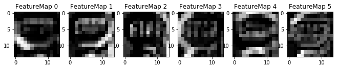

```
>>> conv2 Feature Maps Visualization (conv2 output = 5x5x16):
  Number of Feature Maps  : 16
  Feature Maps Dimensions : 5x5
```

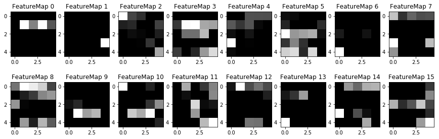

```python
### Visualize your network's feature maps here.
### Feel free to use as many code cells as needed.

# image_input: the test image being fed into the network to produce the feature maps
# tf_activation: should be a tf variable name used during your training procedure that represents the calculated state of a specific weight layer
# activation_min/max: can be used to view the activation contrast in more detail, by default matplot sets min and max to the actual min and max values of the output
# plt_num: used to plot out multiple different weight feature map sets on the same block, just extend the plt number for each new feature map entry

def outputFeatureMap(image_input, tf_activation, activation_min=-1, activation_max=-1 ,plt_num=1):
    # Here make sure to preprocess your image_input in a way your network expects
    # with size, normalization, ect if needed
    # image_input =
    # Note: x should be the same name as your network's tensorflow data placeholder variable
    # If you get an error tf_activation is not defined it may be having trouble accessing the variable from inside a function
    activation = tf_activation.eval(session=sess,feed_dict={x : image_input})
    featuremaps = activation.shape[3]
    plt.figure(plt_num, figsize=(15,15))
    #print('  Number of Feature Maps  : {}'.format(int(len(featuremaps))))
    #print('  Feature Maps Dimensions : {}'.format(featuremaps[0].shape))
    for featuremap in range(featuremaps):
        plt.subplot(6,8, featuremap+1) # sets the number of feature maps to show on each row and column
        plt.title('FeatureMap ' + str(featuremap)) # displays the feature map number
        if activation_min != -1 & activation_max != -1:
            plt.imshow(activation[0,:,:, featuremap], interpolation="nearest", vmin =activation_min, vmax=activation_max, cmap="gray")
        elif activation_max != -1:
            plt.imshow(activation[0,:,:, featuremap], interpolation="nearest", vmax=activation_max, cmap="gray")
        elif activation_min !=-1:
            plt.imshow(activation[0,:,:, featuremap], interpolation="nearest", vmin=activation_min, cmap="gray")
        else:
            plt.imshow(activation[0,:,:, featuremap], interpolation="nearest", cmap="gray")


image_list=[]
with tf.Session() as sess:
    saver.restore(sess, tf.train.latest_checkpoint('.'))
    image = X_Extra_normalized[14]
    image_list.append(image)
    print(image.shape)

    plt.imshow(X_Extra[14])
    plt.show()
    print('>>> conv1 Feature Maps Visualization (conv1 output = 14x14x6) :')
    print ('  Number of Feature Maps  : 6')
    print('  Feature Maps Dimensions : 14x14')
    outputFeatureMap(image_list, conv1, plt_num=1)
    plt.show()
    print('>>> conv2 Feature Maps Visualization (conv2 output = 5x5x16):')
    print ('  Number of Feature Maps  : 16')
    print('  Feature Maps Dimensions : 5x5')
    outputFeatureMap(image_list, conv2, plt_num=2)
    plt.show()
```